```python
%matplotlib inline
import logging # to log
import pandas as pd # to process data using dataframe
import numpy as np # to quickly aggregate the data
import os # to open the files in a correct directory
import matplotlib.pyplot as plt # to plot
from collections import Counter # to quickly estimate the frequency of event occurrence

plt.style.use('ggplot')
plt.style.use('seaborn-whitegrid')

from matplotlib.ticker import MaxNLocator # to plot
```

```python
tesla_light_grey = '#CCCCCC'
tesla_black = '#333333'
tesla_red = '#CC0000'
```

# Parsing the Data

```python
def read_csv(data_dir, data):

    assert data.endswith('csv'), "File has to be in .csv"

    file_path = data_dir + data
    df = pd.read_csv(file_path)
    df.drop('Unnamed: 0', axis=1, inplace=True)
    df.vin = data[:5] #assuring the correct vin name
    df.timestamp_utc = pd.to_datetime(df.timestamp_utc)
    df['year'] = df.timestamp_utc.dt.year
    df['month'] = df.timestamp_utc.dt.month
    df['day'] = df.timestamp_utc.dt.day
    df['doy'] = df.timestamp_utc.dt.dayofyear
    df['time_spent']=df.timestamp_utc.diff().shift(-1)
    df['maxima'] = df.sig_value[(df.sig_value > df.sig_value.shift(1)) & (df.sig_value > df.sig_value.shift(-1))]
    df['minima'] = df.sig_value[(df.sig_value < df.sig_value.shift(1)) & (df.sig_value < df.sig_value.shift(-1))]
    return df
```

```python
def read_csvs(data_dir):
    data_dict={}
    for data in os.listdir(data_dir):
        if data.endswith('csv'):
            df = read_csv(data_dir, data)
            data_dict[data[:5]] = df
    return data_dict
```

```python
# Create Dictionary whose key is the vin number and value is dataframe
data_dict = read_csvs(data_dir='/efs/home/slee/T/')
data_dict['car_0'].head()
```

|  | vin | timestamp_utc | sig_name | sig_value | sig_text | year | month | day | doy | time_spent | maxima | minima |
| --- | --- | --- | --- | --- | --- | --- | --- | --- | --- | --- | --- | --- |
| 0 | car_0 | 2017-09-01 01:24:31.790 | PT_DI_torqueMotor | -1024.0 | SNA | 2017 | 9 | 1 | 244 | 00:00:00.076000 | NaN | NaN |
| 1 | car_0 | 2017-09-01 01:24:31.866 | PT_DI_torqueMotor | -1024.0 | SNA | 2017 | 9 | 1 | 244 | 00:00:00.442000 | NaN | NaN |
| 2 | car_0 | 2017-09-01 01:24:32.308 | PT_DI_torqueMotor | 0.0 | NaN | 2017 | 9 | 1 | 244 | 00:00:00.192000 | NaN | NaN |
| 3 | car_0 | 2017-09-01 01:24:32.500 | PT_DI_torqueMotor | 0.0 | NaN | 2017 | 9 | 1 | 244 | 00:00:00.093000 | NaN | NaN |
| 4 | car_0 | 2017-09-01 01:24:32.593 | PT_DI_torqueMotor | 0.0 | NaN | 2017 | 9 | 1 | 244 | 00:00:00.907000 | NaN | NaN |

#### ▪︎ Min/Max Value

```python
for car, df in data_dict.iteritems():
    print "{}:, Min:{}, Max:{}".format(car, df.sig_value.min(), df.sig_value.max())
```

```
car_6:, Min:-1024.0, Max:439.75
car_7:, Min:-494.25, Max:1320.0
car_4:, Min:-1024.0, Max:434.75
car_5:, Min:-1024.0, Max:439.25
car_2:, Min:-1024.0, Max:439.75
car_3:, Min:-830.25, Max:1248.75
car_0:, Min:-1024.0, Max:438.0
car_1:, Min:-1024.0, Max:439.25
car_8:, Min:-1024.0, Max:440.0
car_9:, Min:-1024.0, Max:440.0
```

→ The result above shows that all the cars except car_3 and car_7 have the same minima

```python
data_dict['car_0'].describe()
```

|  | sig_value | year | month | day | doy | time_spent | maxima | minima |
| --- | --- | --- | --- | --- | --- | --- | --- | --- |
| count | 106116.000000 | 106116.0 | 106116.0 | 106116.000000 | 106116.000000 | 106115 | 17040.000000 | 16631.000000 |
| mean | 12.816990 | 2017.0 | 9.0 | 13.695531 | 256.695531 | 0 days 00:00:16.400279 | 51.256118 | -16.125970 |
| std | 77.538645 | 0.0 | 0.0 | 6.067897 | 6.067897 | 0 days 00:37:28.088381 | 66.617758 | 51.996957 |
| min | -1024.000000 | 2017.0 | 9.0 | 1.000000 | 244.000000 | 0 days 00:00:00 | -116.750000 | -182.000000 |
| 25% | -4.750000 | 2017.0 | 9.0 | 11.000000 | 254.000000 | 0 days 00:00:00.999000 | 11.250000 | -48.750000 |
| 50% | 4.750000 | 2017.0 | 9.0 | 14.000000 | 257.000000 | 0 days 00:00:01 | 38.750000 | -5.250000 |
| 75% | 34.500000 | 2017.0 | 9.0 | 19.000000 | 262.000000 | 0 days 00:00:01.001000 | 73.000000 | 15.000000 |
| max | 438.000000 | 2017.0 | 9.0 | 21.000000 | 264.000000 | 8 days 06:21:52.206000 | 438.000000 | 391.750000 |

#### ▪︎ Further investigation on sig_text and -1024.0

```python
for car, df in data_dict.iteritems():
    if car != "car_3" and car != "car_7":
        print "{}: {}, {}".format(car,
                                  data_dict[car][data_dict[car].sig_value == -1024.0].sig_text.unique(),
                                  data_dict[car][data_dict[car].sig_text == "SNA"].sig_value.unique())
```

```
car_6: ['SNA'], [-1024.]
car_4: ['SNA'], [-1024.]
car_5: ['SNA'], [-1024.]
car_2: ['SNA'], [-1024.]
car_0: ['SNA'], [-1024.]
car_1: ['SNA'], [-1024.]
car_8: ['SNA'], [-1024.]
car_9: ['SNA'], [-1024.]
```

→ Every vehicle (except car_3 and car_7) will have -1024.0 as sig_value if sig_text is SNA, and the converse is true. Confirmed by Han: SNA means ‘signal not available’, for IoT devices, it’s essentially an ‘error’ in data collection. It’s a default value when something went wrong with the measurement. For the purposes of this, feel free to ignore SNA data.

#### ▪︎ Data Observation Period

```python
for key, df in data_dict.iteritems():
    print "{}:, Number of Records:{}, Years:{}, Months:{}, Number of Days:{}".format(key, df.shape[0], df.year.unique(), df.month.unique(), df.doy.max() - df.doy.min())
```

```
car_6:, Number of Records:135422, Years:[2017], Months:[9], Number of Days:28
car_7:, Number of Records:75345, Years:[2113], Months:[1 2 3], Number of Days:75
car_4:, Number of Records:113150, Years:[2017], Months:[9], Number of Days:28
car_5:, Number of Records:88342, Years:[2017], Months:[9], Number of Days:28
car_2:, Number of Records:118595, Years:[2017], Months:[9], Number of Days:28
car_3:, Number of Records:295987, Years:[2113], Months:[1 2 3], Number of Days:86
car_0:, Number of Records:106116, Years:[2017], Months:[9], Number of Days:20
car_1:, Number of Records:107116, Years:[2017], Months:[9], Number of Days:28
car_8:, Number of Records:217050, Years:[2017], Months:[9], Number of Days:28
car_9:, Number of Records:191493, Years:[2017], Months:[9], Number of Days:28
```

# Plot by Day Example

```python
def plot_by_day(car_num, sig_text=True):
    test = data_dict[car_num].copy()
    if not sig_text:
        test = test[test.sig_value != -1024.0]
    test_gp = test.groupby('day')
    groups = test_gp.groups.keys()
    print "Available Days:{}".format(groups)
    fig, axes = plt.subplots(nrows = len(test_gp.groups.keys()), ncols= 1,figsize = (20,100))
    for i, day in enumerate(groups):
        ax = axes.flat[i]
        plot_df = test_gp.get_group(day)
        ax.plot(plot_df.timestamp_utc, plot_df.sig_value, 'o', color=tesla_red, lw=0.1, alpha=0.5)
        ax.set_title(day)
    if car_num == "car_3" or car_num == "car_7":
        ax.set_ylim(-300,460)
    else:
        ax.set_ylim(-450, 1320)
```

```
Available Days:[1, 10, 11, 12, 13, 14, 15, 16, 17, 18, 19, 20, 21]
```

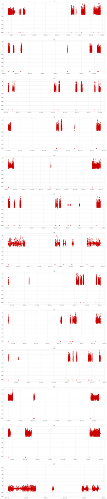

```python
# car_0 with -1024.0
plot_by_day("car_0")
```

```
Available Days:[1, 10, 11, 12, 13, 14, 15, 16, 17, 18, 19, 20, 21]
```

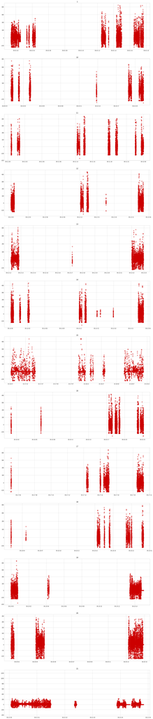

```python
# car_0 without -1024.0
plot_by_day("car_0", False)
```

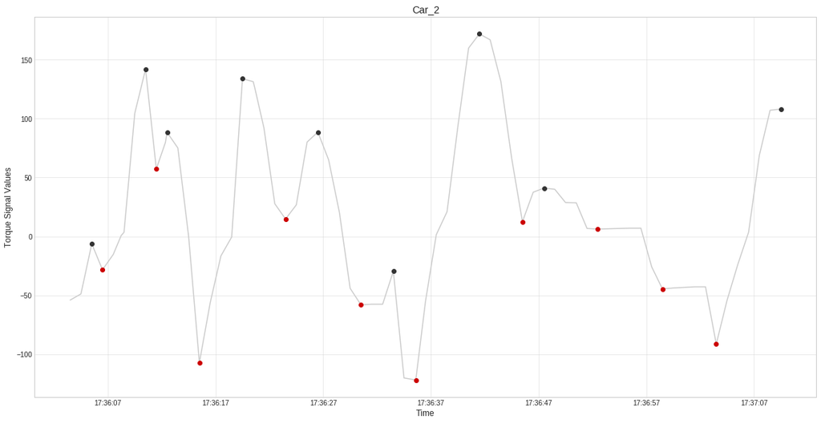

```python
fig, ax = plt.subplots(nrows = 1, ncols = 1,figsize = (20,10))
t2 = data_dict['car_2'].loc[530:600]
max_mask = np.isfinite(t2.maxima)
min_mask = np.isfinite(t2.minima)
ax.plot(t2.timestamp_utc, t2.sig_value, color='#CCCCCC')
ax.set_xlabel('Time')
ax.set_ylabel('Torque Signal Values')
ax.plot(t2.timestamp_utc[max_mask], t2.maxima[max_mask], 'o', color='#333333')
ax.plot(t2.timestamp_utc[min_mask], t2.minima[min_mask], 'o', color='#CC0000')
ax.grid(alpha=0.5)
ax.set_title("Car_2")
```

→ Red: local minima & Black: local maxima → We observe that the current definition does not correctly capture the local minima (look at the consecutive red dots around 17:36:57)

```python
def drop_consecutive_values(df):
    i = 0
    shape_old = df.shape[0]
    shape_new = 0
    while shape_old != shape_new:
        df_shift = df.loc[df.sig_value.shift()!=df.sig_value]
        shape_new = df_shift.shape[0]
        df = df_shift
        i += 1
#         print "{}th iteration: diff is {}".format(i, np.abs(shape_new-shape_old))
        shape_old = shape_new
#     print "After {}th iteration, dropped all the consecutive duplicates".format(i)
    df = df[(~df.maxima.isnull()) | (~df.minima.isnull())].reset_index(drop=True)
    return df

def get_cycle_info(df):
    df['minima'] = df.minima.shift()
    df = df.dropna(axis=0, subset=['maxima', 'minima']).reset_index(drop=True)
    df['amplitude'] = np.abs(df.maxima.values - df.minima.values)
    df['cycle_length'] = df.timestamp_utc.diff().shift(-1).dt.total_seconds()
    return df

def get_largest_cycle(df, n=1, top=True):
    df = drop_consecutive_values(df)
    df = get_cycle_info(df)
    df = df.sort_values('amplitude', ascending=False).reset_index(drop=True)
    if top:
        return df.iloc[:n][['maxima', 'minima','amplitude','cycle_length']]
    else:
        return df.iloc[-n:][['maxima', 'minima','amplitude','cycle_length']]
```

```python
temp = data_dict["car_2"].copy()
temp = drop_consecutive_values(temp)
temp.set_index("timestamp_utc", inplace=True)
temp.head(3)
```

| timestamp_utc | vin | sig_name | sig_value | sig_text | year | month | day | doy | time_spent | maxima | minima |
| --- | --- | --- | --- | --- | --- | --- | --- | --- | --- | --- | --- |
| 2017-09-01 17:12:22.500 | car_2 | PT_DI_torqueMotor | -210.75 | NaN | 2017 | 9 | 1 | 244 | 00:00:01 | NaN | -210.75 |
| 2017-09-01 17:12:24.500 | car_2 | PT_DI_torqueMotor | -181.50 | NaN | 2017 | 9 | 1 | 244 | 00:00:01.001000 | -181.5 | NaN |
| 2017-09-01 17:12:26.500 | car_2 | PT_DI_torqueMotor | -236.00 | NaN | 2017 | 9 | 1 | 244 | 00:00:01.001000 | NaN | -236.00 |

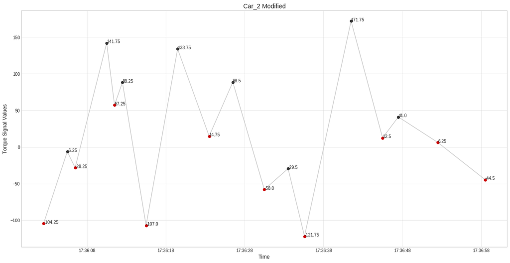

```python
fig, ax = plt.subplots(nrows = 1, ncols = 1,figsize = (20,10))
start = pd.to_datetime('2017-09-01 17:36', format='%Y-%m-%d %H:%M') #matching axis
end = pd.to_datetime('2017-09-01 17:37', format='%Y-%m-%d %H:%M') #matching axis
t2 = temp.loc[start:end]
max_mask = np.isfinite(t2.maxima)
min_mask = np.isfinite(t2.minima)
ax.plot(t2.index, t2.sig_value, color=tesla_light_grey)
ax.set_xlabel('Time')
ax.set_ylabel('Torque Signal Values')
ax.plot(t2.index[max_mask], t2.maxima[max_mask], 'o', color=tesla_black)
ax.plot(t2.index[min_mask], t2.minima[min_mask], 'o', color=tesla_red)
ax.grid(alpha=0.5)
ax.set_title("Car_2 Modified")
for i,j in zip(t2.index,t2.sig_value):
    ax.annotate(str(j),xy=(i,j))
```

#### Comparing Distributions

```python
def compare_metrics():
    metric_collection = {}
    for car, test in data_dict.iteritems():
        metric_collection[car] = {}
        test_temp = test[test.shift().sig_value != test.sig_value]
        test_index = test_temp.index[test_temp.sig_value == -1024.0]

        test_list = []
        for k, idx in enumerate(test_index):
            if k+1 < len(test_index):
                df = test_temp.loc[idx:test_index[k+1]]
                test_list.append(df)

        test_min = []
        test_max = []
        test_mean = []
        test_var = []

        for k, df in enumerate(test_list):
            df = df[df.sig_value != -1024.0]
            test_min.append(df.sig_value.min())
            test_max.append(df.sig_value.max())
            test_mean.append(df.sig_value.mean())
            test_var.append(df.sig_value.std())

        metric_collection[car]['min']=test_min
        metric_collection[car]['max']=test_max
        metric_collection[car]['mean']=test_mean
        metric_collection[car]['var']=test_var

    return metric_collection
```

```python
metric_collection = compare_metrics()
```

[output not shown]

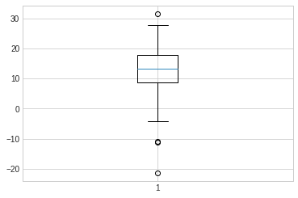

```python
plt.boxplot(metric_collection['car_2']['mean'])
```

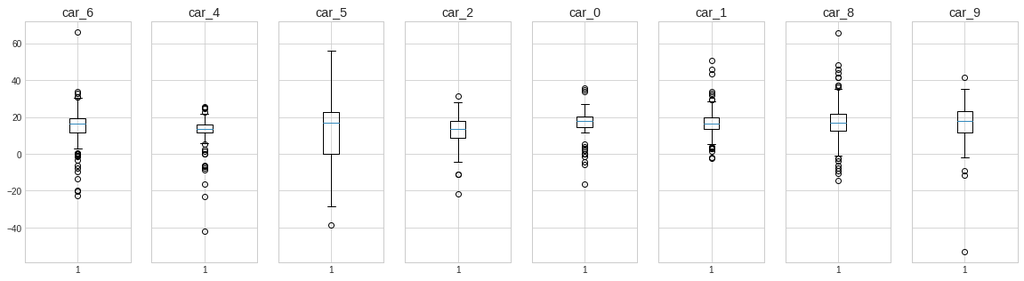

```python
fig, axes = plt.subplots(nrows=1, ncols=8, figsize=(20, 5), sharey=True)

i = 0
for key, val in metric_collection.iteritems():
    if key != 'car_7' and key != 'car_3':
        ax = axes.flat[i]
        ax.boxplot(val['mean'])
        ax.set_title(key)
        i += 1
```

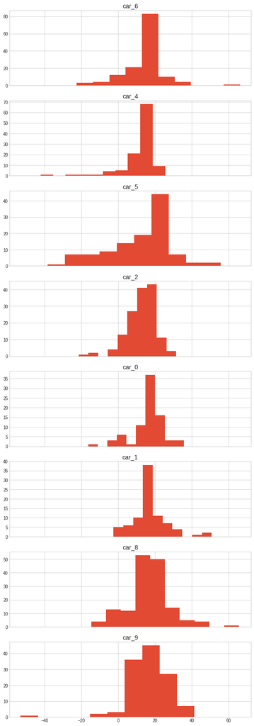

```python
fig, axes = plt.subplots(nrows=8, ncols=1, figsize=(10, 30), sharex=True)

i = 0
for key, val in metric_collection.iteritems():
    if key != 'car_7' and key != 'car_3':
        ax = axes.flat[i]
        ax.hist(val['mean'])
        ax.set_title(key)
        i += 1
```

# Other Metrics

#### ▪︎ Number of Occurence

```python
def get_by_total_occurrence(df, n=1, top=True, start_date=None, end_date=None):
        """
        Get the top N most/least common values by total occurence.

        Args:
            df         (DataFrame): DataFrame that contains full timeseries.
            n          (int): Number of results the user wants to see.
            top        (boolean): If wants to see top results, set to True,
                                if least set to False.
            start_date (str): Start date of the search range. "YYYY-MM-DD"
            end_date   (str): End date of the search range. "YYYY-MM-DD"

        Returns:
            List of top n most/least common values by total occurence.

        """
        df_time = df.set_index('timestamp_utc')
        if start_date:
            df_time = df_time.loc[start_date:]
        if end_date:
            df_time = df_time.loc[:end_date]
        val_count = Counter(df_time.sig_value)
        if top:
            return val_count.most_common()[:n]
        else:
            return val_count.most_common()[-n:]
```

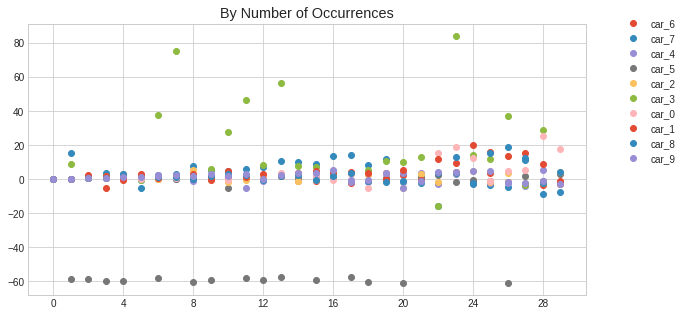

```python
fig, ax = plt.subplots(1,1, figsize=(10,5))
for car, df in data_dict.iteritems():
    df = df[df.sig_value != -1024.0]
    by_freq = get_by_total_occurrence(df, n=30)
    freq_vals = [x[0] for x in by_freq]
#     print "For {}, top_value:{}".format(car, freq_vals)
    ax.plot(freq_vals, 'o', label=car)
    ax.legend(bbox_to_anchor=(1.05, 1.05), loc=2)
    ax.set_title('By Number of Occurrences')
    ax.xaxis.set_major_locator(MaxNLocator(integer=True))
```

#### ▪︎ Total number of time spent

```python
def get_by_total_time_spent(df, n=1, top=True, start_date=None, end_date=None):
    """
    Get the top N most/least common values by total time spent.

    Args:
        df         (DataFrame): DataFrame that contains full timeseries.
        n          (int): Number of results the user wants to see.
        top        (boolean): If wants to see top results, set to True,
                              if least set to False.
        start_date (str): Start date of the search range. "YYYY-MM-DD"
        end_date   (str): End date of the search range. "YYYY-MM-DD"

    Returns:a
        List of top n most/least common values by total time spent.

    """
    df_time = df.set_index('timestamp_utc')
    if start_date:
        df_time = df_time.loc[start_date:]
    if end_date:
        df_time = df_time.loc[:end_date] # remember the days could be different  . .
    df_time = df_time.groupby('sig_value').agg({'time_spent': 'sum'})
    df_time = df_time.sort_values('time_spent', ascending=False)
    if top:
        return df_time.iloc[:n]
    else:
        return df_time.iloc[-n:]
```

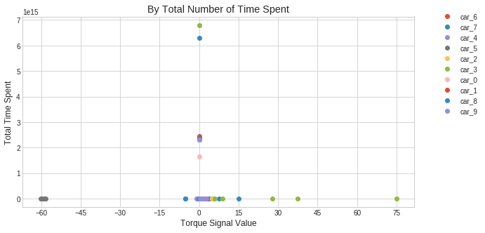

```python
fig, ax = plt.subplots(1,1, figsize=(10,5))
for car, df in data_dict.iteritems():
    by_time = get_by_total_time_spent(df, n=10)
    ax.plot(by_time.index, by_time.time_spent, 'o', label=car)
    ax.legend(bbox_to_anchor=(1.05, 1.05), loc=2)
    ax.set_title('By Total Number of Time Spent')
    ax.xaxis.set_major_locator(MaxNLocator(integer=True))
    ax.set_xlabel("Torque Signal Value")
    ax.set_ylabel("Total Time Spent")
```

One thing we have to remember is that the signal data is not always collected. In other words, there could be a gap between two data points, not because the torque sensor remained at the same value, but merely because the vehicle was not running. We need a better way to distinguish such a case.

```python
def get_by_total_time_spent_2(df, n=1, top=True):
    df_pivot = pd.pivot_table(df, index='day', columns='sig_value',
                              values='time_spent', aggfunc=np.sum,
                              fill_value=0, margins=True,
                              margins_name='Total Time Spent')
    df_unstack = df_pivot.unstack().xs(
        'Total Time Spent', level='day')[:-1]
    df_res = pd.DataFrame(df_unstack).reset_index().rename(
        columns={0: 'total_time_spent'})
    df_res = df_res.sort_values(
        'total_time_spent', ascending=False).reset_index(drop=True).reset_index(drop=True)

    if top:
        return df_res.iloc[:n]
    else:
        return df_res.iloc[-n:]
```

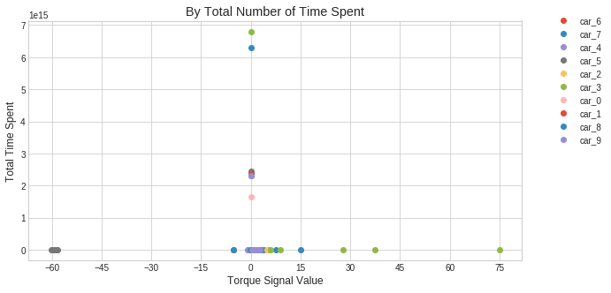

```python
fig, ax = plt.subplots(1,1, figsize=(10,5))
for car, df in data_dict.iteritems():
    by_time = get_by_total_time_spent_2(df, n=10)
    ax.plot(by_time.sig_value, by_time.total_time_spent, 'o', label=car)
    ax.legend(bbox_to_anchor=(1.05, 1.05), loc=2)
    ax.set_title('By Total Number of Time Spent')
    ax.xaxis.set_major_locator(MaxNLocator(integer=True))
    ax.set_xlabel("Torque Signal Value")
    ax.set_ylabel("Total Time Spent")
```

#### ▪︎ Cycle

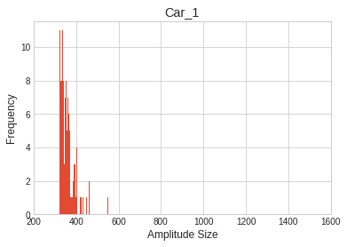

```python
get_largest_cycle(data_dict['car_1'], 100).amplitude.plot.hist(bins=50)
ax = plt.gca()
ax.set_xlim(200,1600)
ax.set_xlabel("Amplitude Size")
ax.set_title("Car_1")
```

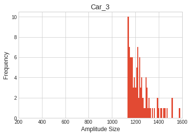

```python
get_largest_cycle(data_dict['car_3'], 100).amplitude.plot.hist(bins=50)
ax = plt.gca()
ax.set_xlim(200,1600)
ax.set_xlabel("Amplitude Size")
ax.set_title("Car_3")
```

→ By setting the x-axis to be on the same scale, we could observe that the two vehicles have apprently different amplitude distribution

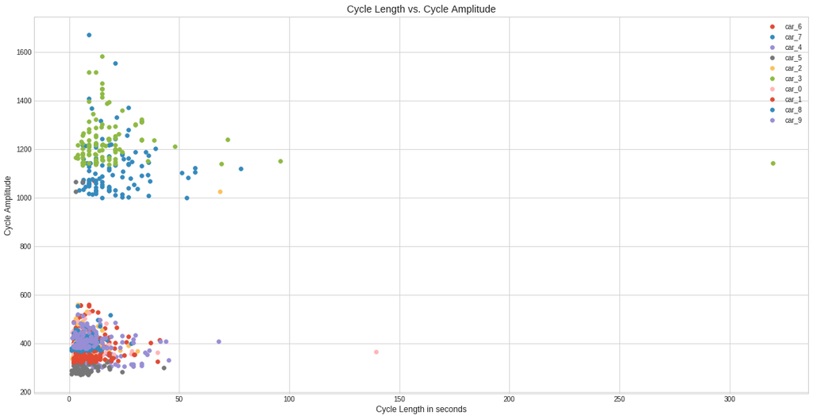

```python
car_index = []
X = []
fig, ax  = plt.subplots(1,1, figsize=(20,10))
for car, df in data_dict.iteritems():
    car_index.append(car)
    data = get_largest_cycle(df, 100)[['amplitude', 'cycle_length']]
    ax.scatter(x = data.cycle_length, y = data.amplitude, label=car)
    X.append(data.amplitude)
ax.legend()
ax.set_xlabel("Cycle Length in seconds")
ax.set_ylabel("Cycle Amplitude")
ax.set_title("Cycle Length vs. Cycle Amplitude")
```

→ We assume that the vechiles with more frequent torque value changes, explained by high cycle amplitude & short cycle length, are more prone to experience damage accrual. Thus the answer should be car_3 and car_7. We can come to this conclusion by a simple visualization!

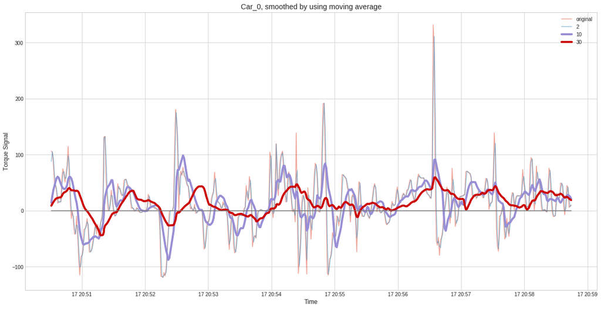

```python
test = data_dict['car_0'].copy()
test['time_spent']=test.timestamp_utc.diff().shift(-1).dt.total_seconds()
test['rolling_10'] = test.sig_value.rolling(10).mean()
test['rolling_30'] = test.sig_value.rolling(30).mean()
test['rolling_2'] = test.sig_value.rolling(2).mean()
test=test[test.sig_value != -1024.0]
test = test.loc[70000:70500]
fig, ax = plt.subplots(1,1, figsize=(20,10))
ax.plot(test.timestamp_utc, test.sig_value, alpha=0.5, label="original")
ax.plot(test.timestamp_utc, test.rolling_2, alpha=0.5, label="2")
ax.plot(test.timestamp_utc, test.rolling_10, linewidth=4, label="10")
ax.plot(test.timestamp_utc, test.rolling_30, linewidth=4, color=tesla_red, label="30")
ax.plot(test.timestamp_utc, [0]*len(test.timestamp_utc), '-')
ax.set_title("Car_0, smoothed by using moving average")
ax.set_xlabel("Time")
ax.set_ylabel("Torque Signal")
ax.legend()
```